# Партиции, файловые системы, монтирование

Майоров Дмитрий Андреевич

# Информация

## Докладчик

- Майоров Дмитрий Андреевич

# Цель работы

Получить навыки создания разделов на диске и файловых систем. Получить навыки монтирования файловых систем

# Выполнение лабораторной работы

Добавляем к нашей виртуальной машине два диска размером 512МБ

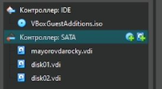

Рисунок 1

# Выполнение лабораторной работы

Запускаем ВМ. Получаем полномочия администратора. Смотрим перечень разедлов на всех в системе устройствах жестих дисков

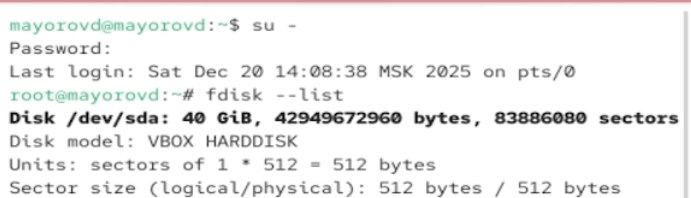

Рисунок 2

# Выполнение лабораторной работы

Начинаем делать разметку диска

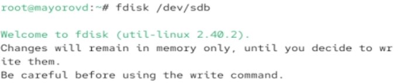

Рисунок 3

# Выполнение лабораторной работы

Делаем разметку диска с помощью различных команд

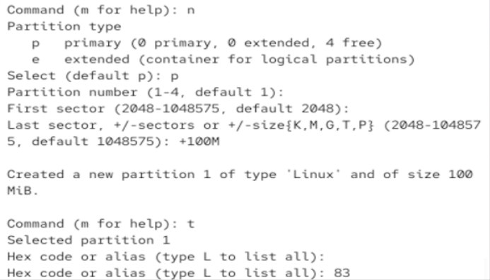

Рисунок 4

# Выполнение лабораторной работы

Вводим две команды. Первая нужна для детального анализа разделов. Вторая для быстрого списка устройств на уровне ядра

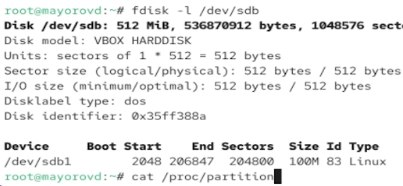

Рисунок 5

# Выполнение лабораторной работы

# Выполнение лабораторной работы

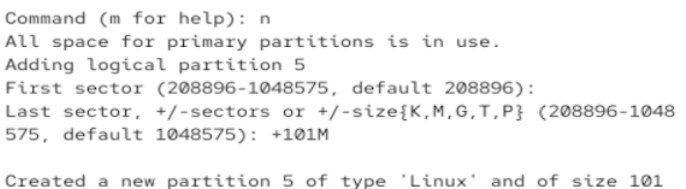

Рисунок 7

# Выполнение лабораторной работы

# Выполнение лабораторной работы

Смотрим информацию о добавленных разделах

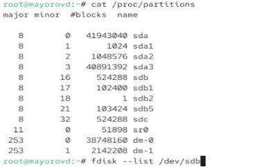

Рисунок 9

# Выполнение лабораторной работы

Снова работаем с разметкой диска. ВЫбираем новый тип раздела

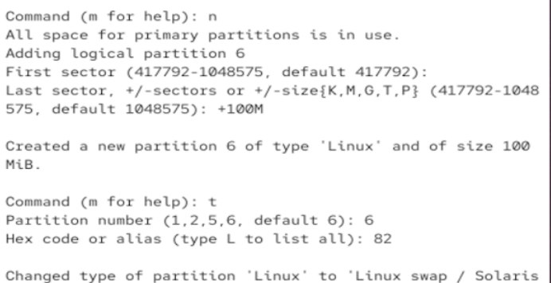

Рисунок 10

# Выполнение лабораторной работы

Записываем изменения в таблицу разделов ядра и смотрим информацию о добавленных разделах

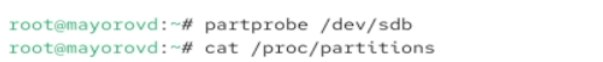

Рисунок 11

# Выполнение лабораторной работы

Форматируем раздел прокачки. Включаем вновь выделенное пространство и просматриваем размер пространства прокачки, которое выделено в настоящий момент

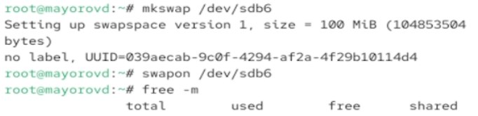

Рисунок 12

# Выполнение лабораторной работы

Смотрим таблицы разделов и разделы на втором добавленном нами диске

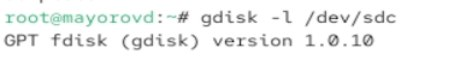

Рисунок 13

# Выполнение лабораторной работы

Создаем раздел

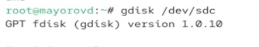

Рисунок 14

# Выполнение лабораторной работы

Работаем с разметкой диска

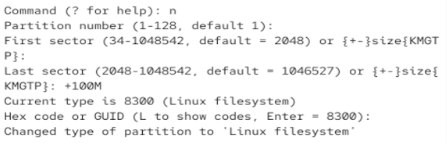

Рисунок 15

# Выполнение лабораторной работы

Записываем изменения в таблицу разделов ядра и смотрим информацию о добавленных разделах

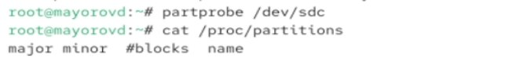

Рисунок 16

# Выполнение лабораторной работы

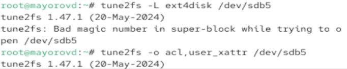

Рисунок 17

# Выполнение лабораторной работы

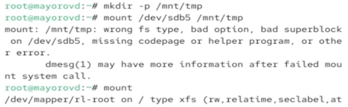

Рисунок 18

# Выполнение лабораторной работы

Создаем точку монтировнаия для раздела XFS. Смотрим информацию об идентификаторах блочных устройств

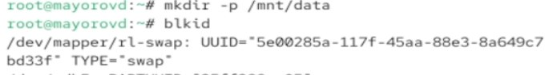

Рисунок 20

# Выполнение лабораторной работы

Открываем файл /etc/fstab для редактирования и добавляем нужную нам строку

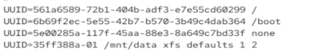

Рисунок 21

# Выполнение лабораторной работы

Монтриуем и проверяем что раздел примонтирован правильно

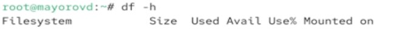

Рисунок 23

# Выводы

Получены навыки создания разделов на диске и файловых систем. Получить навыки монтирования файловых систем

:::